## Box plots

Box plots (sometimes called box and whisker plots) visualise the quantiles of a continuous variable. A box plot the minimum, lower quartile, median, upper quartile and maximum values. In ggplot2, the `geom_boxplot()` function is used to produce box plots. The data used in the examples comes from the `{palmerpenguins}` package.

### Basic boxplots

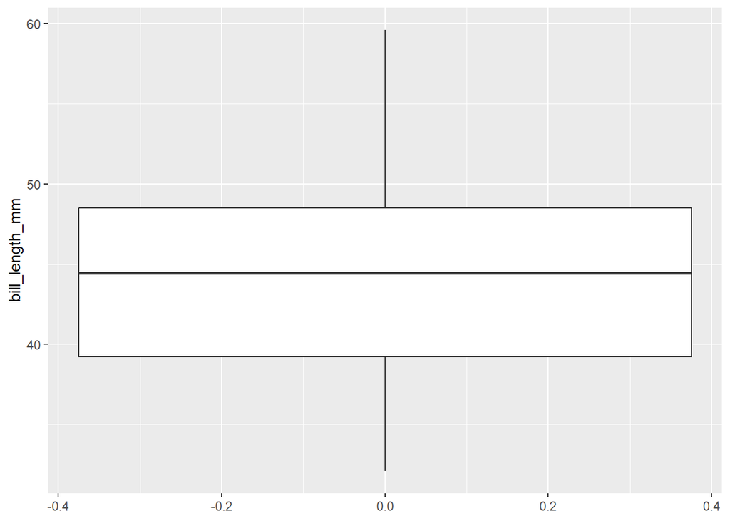

```r
ggplot(data = penguins,
       mapping = aes(y = bill_length_mm)) +
  geom_boxplot()
```

### Adding points

To better show the distribution of values, points can be overlain on the boxplot using `geom_jitter()`. `geom_jitter()` works similarly to `geom_point()` but adds some random noise. This is useful when displaying values, as otherwise the points would lie on a straight line. `geom_jitter()` requires both `x` and `y` values to be specified so we can set the value of `x` (or `y` if a horizontal boxplot was chosen) as `0` for all points.

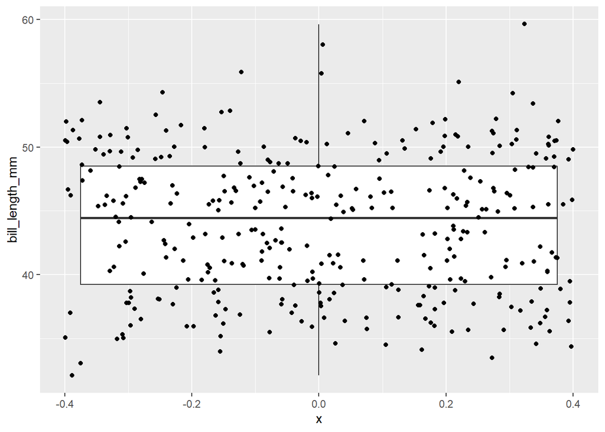

```r
ggplot(data = penguins,
       mapping = aes(y = bill_length_mm)) +
  geom_boxplot() +
  geom_jitter(aes(x = 0))
```

### Multiple categories

The distribution of multiple (discrete) categories can be visualised by setting the `x` (or `y` if horizontal boxplots are desired).

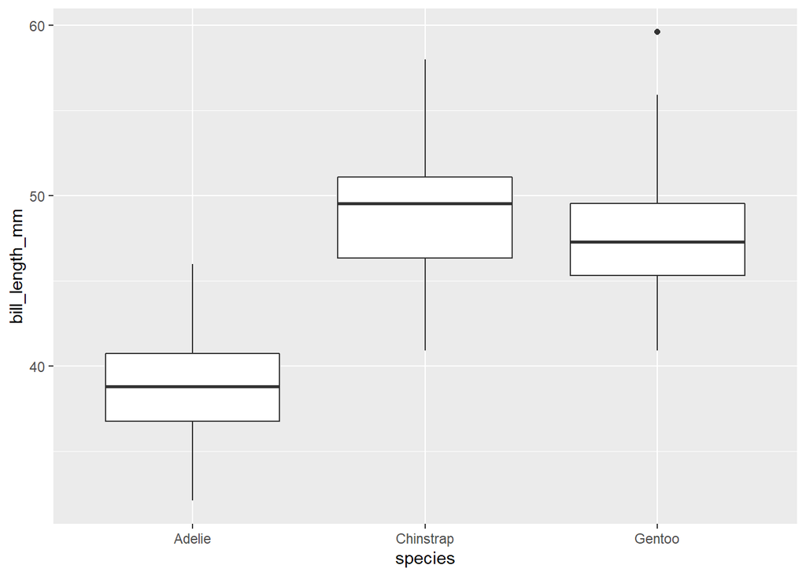

```r
ggplot(data = penguins,
       mapping = aes(x = species,
                     y = bill_length_mm)) +
  geom_boxplot()
```

### Adding colour

There are two ways to add colour to boxplots: (i) using `colour` (or `color`) which changes the colour of the outline of boxplots; (ii) using `fill` which changes the colour of the inner area of the boxes. If `colour` or `fill` is set outside the `aes()` function, it must be a valid colour name, and will set the same colour for all box plots. If `colour` or `fill` is set inside the `aes()` function, the colours will change based on the value of a variable. Here, the `fill` changes based on the `species`.

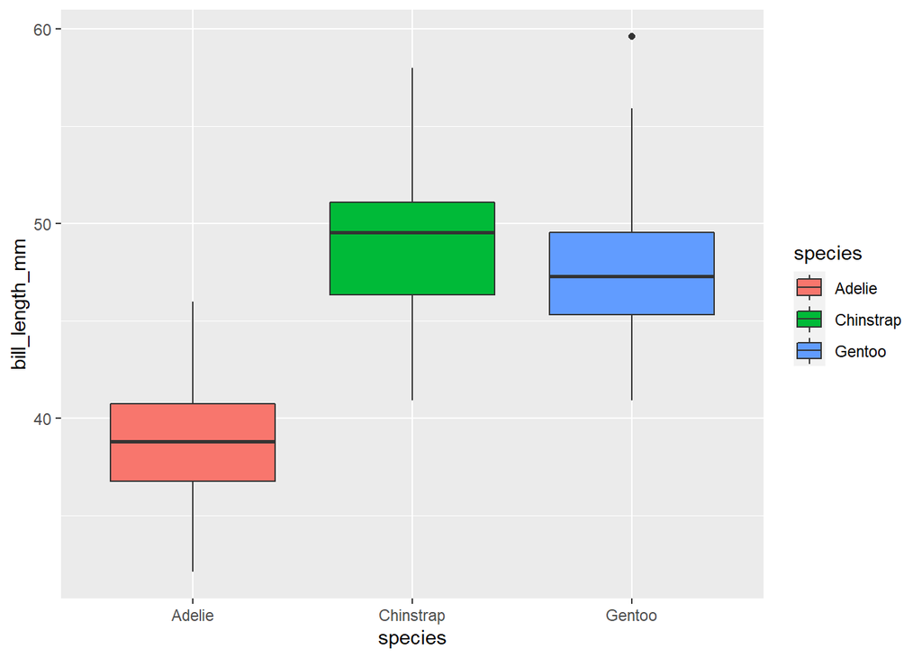

```r
ggplot(data = penguins,
       mapping = aes(x = species,
                     y = bill_length_mm,
                     fill = species)) +
  geom_boxplot()
```

### Final version

Since the colours change in the same way as the values on the x-axis, a legend is not needed in this plot. The legend can be hidden using `theme(legend.position = "none")`. A title, subtitle, caption, and axis titles are set through the `labs()` function. The built-in minimalist {ggplot2} theme is added in here using `theme_minimal()`.

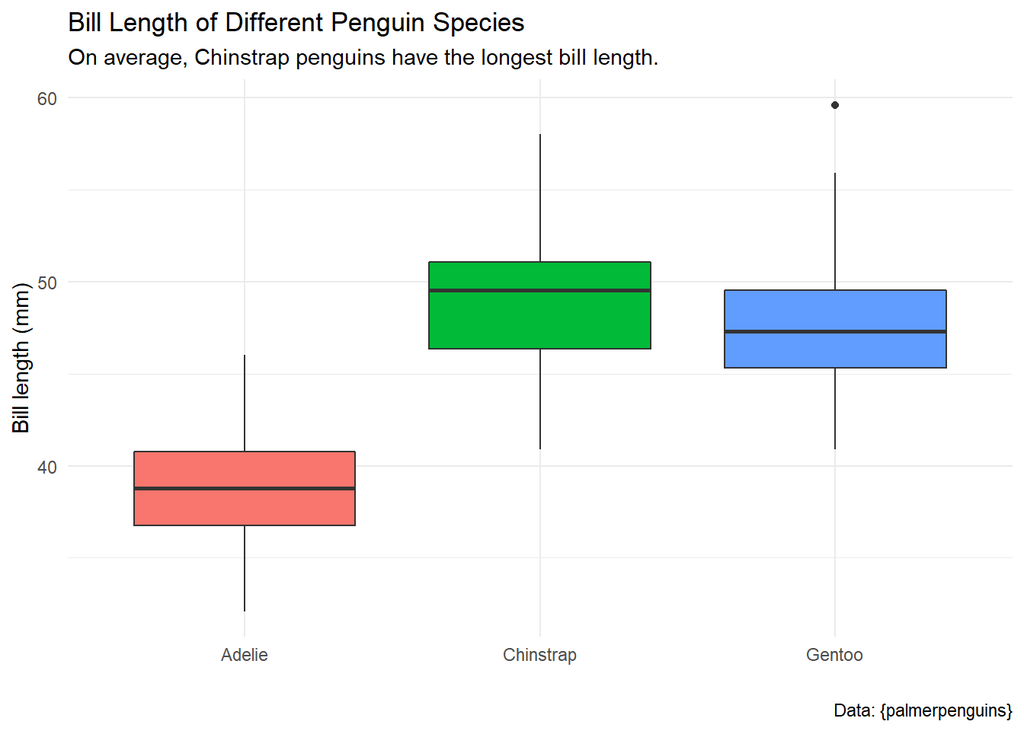

```r
ggplot(data = penguins,
       mapping = aes(x = species,
                     y = bill_length_mm,
                     fill = species)) +
  geom_boxplot() +
  theme_minimal() +
  labs(title = "Bill Length of Different Penguin Species",
       subtitle = "On average, Chinstrap penguins have the longest bill length.",
       caption = "Data: {palmerpenguins}",
       x = "",
       y = "Bill length (mm)") +
  theme(legend.position = "none")
```